# Tarea 5 Ecuaciones Diferenciales Ordinarias

## 1. Presión Barométrica

**La presión barométrica p a una determinada altura h, esta descrita por la siguiente ecuación diferencial.**

$$ \dfrac{dP}{dh} = -\dfrac{mg}{Tk_B} P$$

**Donde m es la masa de una molécula, g es el valor de la gravedad, $k_B$ la constante de Boltzmann, y T el valor de la temperatura.**

**(i)Investiga la altura h sobre el nivel del mar de la Ciudad de México y del pico de Orizaba. Hecho esto calcula la variación barométrica resolviendo la EDO con el método de tu preferencia. Considera Po = 1, kB = 1, m = 1, y T = 25◦C. Realiza en una gráfica h vs P, las variaciones de la presión de la CDMX y del pico de Orizaba, donde la altura estará comprendida entre h = 0 y hmax de cada lugar.**

Vimos en clase que si escribimos una ec. diferencial como $$\frac{dx}{dt}=f(x,t)$$

Entonces podemos resolverla en el intervalo $[a,b]$ usando el método de Runge Kutta de 4to orden. Que es un método iterativo de N pasos, en el que en cada paso nos movemos una distancia $h = (b-a)/N$ desde $a$ hasta $b$ usando:

$$ k_1=hf(x,t) $$$$ k_2=hf(x+0.5k_1,t+0.5h) $$$$ k_3=hf(x+0.5k_2,t+0.5h) $$$$ k_4=hf(x+k_3,t+h) $$$$ x(t+h)=x(t)+\frac{(k_1+2k_2+2k_3+k_4)}{6.} $$

```python
#Runge Kutta de orden 4
from pylab import *




# Hacemos el método de Runge aplicado a la ecuación dx/dt = f(x,t),
#en el intervalo de a hasta b con N pasos
# x0 es el valor de la solución en el punto t =0

# La función da como resultado el valor de la solución en el punto b
# Además, tiene el parámetro "gráfica" que si lo dejamos en True
# hace que se grafique la solución
def runge(f,a,b,N,x0,grafica=True,ejex ='t',ejey='x(t)'):
    #calculamos h
    h=(b-a)/N

    #iniciamos la variable dependiente desde el valor inicial a
    t=a
    #cremos una lista donde guardaremos los valores de t y de x(t)
    puntos_t=[]
    puntos_x=[]

    # iniciamos la variable x en el valor que debe de tomar en t=0
    x = x0
    #vamos iterando la t en valores que van de a hasta b en pasos de longitud h
    for t in arange(a,b,h):
        #agregamos el valor de x a la lista
        puntos_x.append(x)

        # calculamos el siguiente valor de x usando el metodo Runge Kutta
        k1=h*f(x,t)
        k2=h*f(x+0.5*k1,t+0.5*h)
        k3=h*f(x+0.5*k2,t+0.5*h)
        k4=h*f(x+k3,t+h)
        x+=(k1+2*k2+2*k3+k4)/6.0

        #también agregamos el valor de t a la lista de valores de t
        puntos_t.append(t)

    # si el parámetro gráfica está en True:
    if grafica:
        #Vamos a graficar la solución y ponerle nombre a los ejes
        plot(puntos_t,puntos_x)
        xlabel(ejex)
        ylabel(ejey)
        show()
    #En cualquier caso, regresamos el último punto de x
    # Que es la solución evaluada en b
    return(puntos_x[-1])
```

Primero definimos los valores de las constantes. Puse directamente los valores reales de las constantes en vez de $P = k_b = m = 1$. Esto porque con estos valores igualados a 1, obtenía soluciones que crecían o decrecían demasiado rápido y porque entonces los valores de las alturas para la cdmx y el pico de orizaba en metros no coincidían con las unidades usadas para las otras variables

```python
#Valores para la altura en la cdmx y en el pico:
hcdmx = 2250
hpico = 5636

# Puse como presión atmosférica en h=0 que P =101325
# (es decir, medido en Pascales)

P0=101325

# Puse el valor de kb en el SI
kb = 1.3806*1e-23
# Y m es la masa de una partícula de aire, que en promedio tienen una masa
# molar de 0.02897 y por tanto una masa por particula de:
m=0.02897/(6.022*1e23)

# el valor de g y la teperatura pasada a Kelvin
g=9.81
T=25+273.15
```

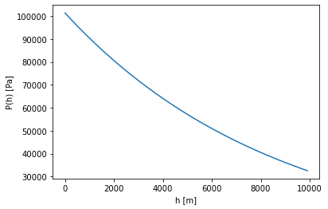

```
32566.955768463322
```

```python
# definimos la funcion que está del lado derecho de la ecuación diferencial
# que es la función f que se usa en el programa de Runge Kutta
# Depende de la variable dependiente P y la independiente h de la ec. diferencial
def f(P,h):
    return(-m*g/(T*kb)*P)



# Hacemos un primer cálculo con una altura que va de 0 a 10,000 m
# Usando N=100 iteraciones, para ver que tenga sentido
runge(f,0,10000,100,P0,ejex='h [m]',ejey='P(h) [Pa]')
```

Vemos como baja la presión con la altura, hasta llegar a un valor de 32567 pascales a los 10,000 m sobre el nivel del mar. Intuitivamente la gráfica tiene sentido

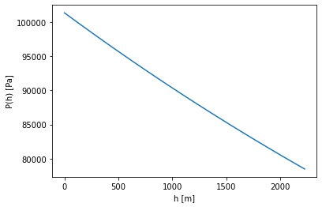

```
Presión en la cdmx: 78488.35673 Pa
```

```python
# Para la ciudad de Mexico, usamos la altura de la ciudad
res = runge(f,0,hcdmx,100,P0,ejex='h [m]',ejey='P(h) [Pa]')

# imprimimos el resultado de la presión
print('Presión en la cdmx: ' + str(round(res,5)) + ' Pa')
```

Este valor de 78488 Pa coincide con el valor que se suele dar para la ciudad de México, que es de 586mm Hg = 0.77 atm.

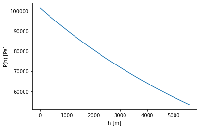

```
Presión en el pico : 53443.62887 Pa
```

```python
# Para el pico de Orizaba
res = runge(f,0,hpico,100,P0,ejex='h [m]',ejey='P(h) [Pa]')

print('Presión en el pico : ' + str(round(res,5)) + ' Pa')
```

**(ii) Para la Ciudad de México vuelve a calcular la presión final (el ultimo valor de presión al resolver la EDO) si ahora la temperatura varia en un intervalo $T = [0^o, 35^oC]$ con 200 valores. Gráfica la temperatura vs la presión final.**

**Para analizar mejor las gráficas usa escala logarítmica en ambos ejes. Comenta los resultados con tus propias palabras.**

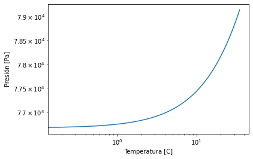

```python
# Creamos una lista vacía donde guardaremos las presiones
presiones=[]

#Vamos iterando la temperatura desde 0 hasta 35 en 200 pasos
for T in np.linspace(0,35,200):
    #Ponemos otra vez los valores de las constantes,
    # Para que la función no dependa de que se corra la celda de arriba
    hcdmx = 2250
    P0=101325
    kb = 1.3806*1e-23
    m=0.02897/(6.022*1e23)
    g=9.81
    # Pasamos la temperatura a Kelvin
    T=T+273.15

    #Agregamos a la lista de presiones la presión calculada por runge
    #kutta a esta altura y con la temperatura T

    # Para ello, hay que ir redefiniendo la función del lado derecho
    # de la ec. diferencial para cada valor de T
    # Calculamos hasta una altura de la hcdmx
    # El último False es para que no grafique nada cada que la corramos
    presiones.append(runge(lambda P,h: -m*g/(T*kb)*P,0,hcdmx,100,P0,False))

#graficamos las temperaturas y presiones y lo hacemos logarítmico
plt.plot(np.linspace(0,35,200),presiones)
plt.yscale('log')
plt.xscale('log')
plt.xlabel('Temperatura [C]')
plt.ylabel('Presión [Pa]')
```

## Ecuaciones de Segundo Orden

#### 2. El movimiento planetario

**Usando la ley de gravitación universal y la segunda ley de newton, gráfica la orbita de la tierra y de otros dos planetas (los de tu preferencia).**

Según la ley de gravitación universal, la fuerza es de $F = -\dfrac{GMm}{r^2} \widehat{r}$, que en coordenadas cartesianas es de $F = - G \dfrac{mM}{(x^2+y^2)^{(3/2)}} (x\widehat{x} + y\widehat{y})$ con M la masa del sol

La igualamos a $F = m \vec{a} = \ddot{x} \widehat{x} + \ddot{y} \widehat{y}$

Entonces nos quedan las dos ecuaciones diferenciales:

$$ \ddot{x} = -\dfrac{GMx}{(x^2+y^2)^{3/2}} $$$$ \ddot{y} = -\dfrac{GMy}{(x^2+y^2)^{3/2}} $$

Para resolver el sistema, definimos dos variables $v_x = \dot{x}$ y $v_y = \dot{y}$ para tener un sistema de 4 ecuaciones diferenciales de primer orden:

$$ \dfrac{dx}{dt} = v_x$$$$ \dfrac{dv_x}{dt} = - \dfrac{GMx}{(x^2+y^2)^{3/2}}$$

$$ \dfrac{dy}{dt} = v_y$$ $$ \dfrac{dv_y}{dt} = - \dfrac{GMy}{(x^2+y^2)^{3/2}}$$

Lo resolveremos con el método de Runge Kutta tal como lo vimos en clase

```python
from IPython import display

import numpy as np
import matplotlib.pyplot as plt

# Definimos la función que toma los valores actuales de x,y,vx,vy (en una lista r)
# Y devuelve los valores de sus derivadas según la ec. diferencial

# La función toma el valor de r, el tiempo t y M y G (predeterminados a la masa del sol y el valor de G en SI)
def f(r,t,M=1.988*10**30,G=6.61*10**(-11)):
    #Tomamos los valores de las variables desde la lista r
    x = r[0]
    vx = r[1]
    y = r[2]
    vy = r[3]

    #calculamos la derivada de cada variable según la ec. diferencial
    fx = vx
    fvx = -M*G*x/((x**2+y**2)**(3/2))
    fy = vy
    fvy= -M*G*y/((x**2+y**2)**(3/2))

    #regresamos esta lista de derivadas
    return array([fx,fvx,fy,fvy],float)
```

Definiremos una función "orbita" que toma como entrada la posición x0 y y0 del planeta a un tiempo t=0 (en metros y respecto a la posición del sol que se considera fijo). También toma los valores de la velocidad inicial en la dirección x y en la dirección y del planeta. Luego toma el valor tf, que es el último tiempo en el que queremos conocer la posición del planeta, medido en s. Toma también el número de iteraciones N que haremos en el Runge Kutta y el título que le daremos a la gráfica resultante.

Luego, aplica el método de Runge Kutta con N iteraciones hasta llegar al tiempo tf. Y va guardando las posiciones x,y del planeta y las velocidades vx,vy para cada tiempo en listas.

Como resultado, grafica la órbita del planeta

```python
#definimos la función
def orbita(x0,y0,vx0,vy0,tf,N=100, titulo="órbita"):
    #empieza desde un tiempo 0
    t0 = 0
    #definimos la longitud de cada paso
    h = (tf-t0)/N

    # creamos la lista de puntos de tiempo
    tpuntos = np.arange(t0,tf,h)

    #y de posiciones y velocidades vacías por ahora
    xpuntos = []
    vxpuntos = []
    ypuntos = []
    vypuntos = []


    #ponemos los primeros valores iniciales
    r = array([x0,y0,vx0,vy0],float)

    #vamos iterando sobre los tiempos
    for t in tpuntos:
        #agregamos el punto de x , y y velocidades actuales a la lista
        xpuntos.append(r[0])
        vxpuntos.append(r[1])
        ypuntos.append(r[2])
        vypuntos.append(r[3])

        #aplicamos runge Kutta para este sistema de ecuaciones
        #usando la función f que toma las posiciones y velocidades actuales y devuelve sus derivadas
        k1 = h*f(r,t)
        k2 = h*f(r+0.5*k1,t+0.5*h)
        k3 = h*f(r+0.5*k2,t+0.5*h)
        k4 = h*f(r+k3,t+h)
        r += (k1+2*k2+2*k3+k4)/6

    #Al terminar la iteración, hacemos una gráfica de los puntos de la órbita
    plt.plot(xpuntos,ypuntos)
    plt.xlabel("x [m]")
    plt.ylabel("y [m]")

    # Ponemos los límites de las variables en la gráfica
    # que sean 1.4 veces la distancia del planeta al sol al inicio, para que seguramente se vea la
    # órbita completa
    rad = (x0**2+y0**2)**0.5
    plt.xlim(-rad*1.4,rad*1.4)
    plt.ylim(-rad*1.4,rad*1.4)

    #Dibujamos un sol en el centro
    plt.plot(0,0,'y*',markersize=18)

    #Y un planeta en el último punto de la órbita
    plt.plot(xpuntos[-1],ypuntos[-1],'bo')

    #para que la gráfica tenga un aspect ratio de 1:1 y no esté distorcionada
    plt.gca().set_aspect('equal')
    #agregamos título
    plt.title(titulo)
    plt.show()

    #Esta línea es para que después podamos hacer la gráfica animada
    #básicamente elimina la gráfica actual para poder dibujar sobre ella y así poder ir actualizando
    # la gráfica
    display.clear_output(wait=True)
```

Empezamos con la órbita de la Tierra. Para ello, usamos la función órbita creada. Necesitamos meter los valores iniciales de posición y velocidad.

Para eso, supuse que a t=0 la Tierra se encuentra en su afelio (posición más alejada del sol, que es de $152.1 * 10^9m$ en el caso de la Tierra) y lo alineamos con el eje x. Además, en dicho momento se mueve a su mínima velocidad, que es de 29140 m/s según datos de la NASA (https://nssdc.gsfc.nasa.gov/planetary/factsheet/earthfact.html)

Por ello, ponemos como condiciones iniciales que se encuentra en una posición de x,y =$(152.1 * 10^9m,0)$ y con una velocidad de $vx,vy = (0,29140 m /s)$

Por último, puse como tiempo final la cantidad de segundos en un año, para que se muestre justo una vuelta completa.

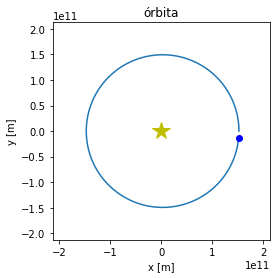

```python
# orbita de la Tierra

orbita(152.1*10**9,0,0,29.14*10**3,365.25*24*60*60)
```

Vemos que tiene una órbita bastante circular. Y que completa casi una vuelta completa en 365 días, justo como esperado (no da la vuelta completa como debería porque muchos valores están redondeados y porque hicimos pocas iteraciones en el método de Runge Kutta por lo que los resultados no son exactos)

También podemos hacer que se vaya dibujando la órbita de manera animada. Para ello, simplemente llamamos la función para distintos tiempos finales y que vaya graficando cada uno.

En este caso, vamos a graficar desde el día 1 hasta el 365 con 50 iteraciones (en cada iteración dejamos pasar como 7 días). Para cada una de estas iteraciones, calculamos la cantidad de segundos transcurridos (número de días *24*60*60) y aplicamos la función órbita con la condición de que pare en esta cantidad de segundos.

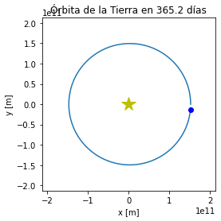

```python
# Órbita de le Tierra

#Iteramos para distinta cantidad de días desde 1 hasta 365
for dias in np.linspace(1,365.25,50):
    #vamos aplicando la función órbita
    orbita(152.1*10**9,0,0,29.14*10**3,dias*24*60*60,
           titulo="Órbita de la Tierra en {} días".format(round(dias,1)))
```

Podemos así ver el movimiento de la Tierra en su órbita y vemos que hace una revolución en aprox 365 días, como debería.

Ahora hacemos lo mismo para **Mercurio**. Usando nuevamente datos de su posición y velocidad en el afelio como datos iniciales https://nssdc.gsfc.nasa.gov/planetary/factsheet/mercuryfact.html. Y nuevamenre graficamos la órbita animada. Esta vez para tiempos de 1 a 100 días (días terrestres).

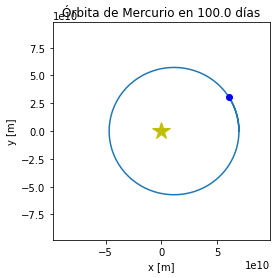

```python
# Órbita de Mercurio
for dias in np.linspace(1,100,100):
    orbita(69.82*10**9,0,0,38.89*10**3,dias*24*60*60,
           titulo="Órbita de Mercurio en {} días".format(round(dias,1)))
```

Vemos que toma aproximadamente 87-90 días en dar una vuelta completa (podríamos ir variando el programa para ver bien cuánto tarda). Resulta que el periodo real de la órbita de Mercurio es de 88 días, así que el programa lo predice bastante bien.

Además, vemos que tiene una órbita mucho más elíptica que la de la tierra, lo cual es cierto según los datos de la Nasa, pues tiene una eccentricidad de 0.2

Finalmente hacemos lo mismo para **Neptuno**, usando al igual que antes su posición y velocidad en el afelio https://nssdc.gsfc.nasa.gov/planetary/factsheet/neptunefact.html. Esta vez lo animamos en un tiempo total de 70,000 días, pues recorre su órbita en mucho más tiempo que la Tierra y Mercurio

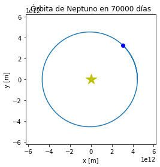

```python
# Órbita de Neptuno
for dias in np.linspace(1,70000,70):
    orbita(4445*10**9,0,0,5.5*10**3,dias*24*60*60,
           titulo="Órbita de Neptuno en {} días".format(round(dias)))
```

Vemos en la animación que tiene un periodo de aprox 60,000, lo que coincide con el verdadero valor de 60,189, por lo que nuestro programa lo predice bien. Además, es una órbita muy circular, lo que coincide con la información de la Nasa que dice que tiene una eccentricidad de a penas 0.011

## 3. Fuerza de arrastre en caída libre

**La fuerza de arrastre FD que actúa sobre cierto objeto en caída libre, puede ser aproximada por** $$ F_D = a v^2 e^{-by}$$

**donde ν es la velocidad del objeto, y la altura, mientras que a y b son constantes que dependen del objeto y del fluido.**

**El termino exponencial explica el cambio de la densidad del aire con la altura. La ecuación diferencial que describe la caída del objeto es**

$$m \ddot{y} = -mg + F_D$$

**(i) Encuentra el tiempo t en que el objeto toca el suelo, para ello soluciona la ecuación diferencial si y(0) = 9000 m y $\dot{y}(0) = 0$. Considera el valor de las siguientes constantes $m = 114 kg, a = 7.45 kg/m \; , b = 10.53 \times 10^{-5} m^{-1} , g = 9.8 m/s^2$**

Como vimos en clase, el truco es plantear otra variable $v=\frac{dy}{dt}$, tal que el sistema se reduzca a un sistema de dos ecuaciones lineales acopladas: $$ \frac{dy}{dt}=v\\ \frac{dv}{dt} = -g + F_D/m $$

Definimos la función f que toma como entrada el valor de y y v actuales y el tiempo t actual y devuelve sus derivadas según dice la ec. diferencial

```python
from IPython import display

import numpy as np
import matplotlib.pyplot as plt

g = 9.81

# la función también toma como entrada los valores de los parámetros a y b
def f(r,t,a,b,m):
    y = r[0]
    vy = r[1]

    fy = vy
    fvy= -g + a*vy**2*np.exp(-b*y)/m



    return array([fy,fvy],float)
```

Definimos la función caida

Para una y0 inicial y velocidad vy0 incial, la función va resolviendo la ecuación diferencial presentada arriba hasta llegar a que el valor de y es menor que 0 (cuando choca con el piso) y se detiene ahí y devuelve el tiempo transcurrido.

La función también toma como entrada los valores de los parámetros a,b,m.

La función va haciendo pasos de tamaño h (que h es otra entrada de la función). Y cada freq pasos (donde freq es otra entrada de la función, predeterminada a 50), se actualiza una gráfica de y vs t.

```python
#definimos la función
def caida(y0,vy0,h,a=7.45,b=10.53*10**(-5),m=114
          , titulo="Caida con arrastre",
         freq =50):

    #Inicializamos el tiempo y un contador de la cantidad de pasos que hemos hecho
    t = 0
    count = 0

    #inicializamos las listas de puntos t,y,vy
    tpuntos = []
    ypuntos = []
    vypuntos = []

    #valor inicial de las variables
    r = array([y0,vy0],float)

    #mientras la altura sea mayor que 0, vamos a seguir iterando
    while r[0] > 0:
        #agregamos el tiempo actual, y actural y vy actual a las listas
        tpuntos.append(t)
        ypuntos.append(r[0])
        vypuntos.append(r[1])


        #aplicamos Runge Kutta
        k1 = h*f(r,t,a,b,m)
        k2 = h*f(r+0.5*k1,t+0.5*h,a,b,m)
        k3 = h*f(r+0.5*k2,t+0.5*h,a,b,m)
        k4 = h*f(r+k3,t+h,a,b,m)
        r += (k1+2*k2+2*k3+k4)/6

        #cada que el contador sea un múltiplo de freq, vamos a graficar

        if count % freq == 0:
            #graficamos los puntos t y y
            plt.plot(tpuntos,ypuntos)
            plt.xlabel("t [s]")
            plt.ylabel("y [m]")
            plt.xlim(0,t*1.1)
            plt.ylim(0,y0*1.1)

            #en el punto actual dibujamos una pelotita
            plt.plot(tpuntos[-1],ypuntos[-1],'bo')
            #le damos un título según la cantidad de segundos que han pasado
            plt.title(titulo + ' ' + str(round(t,2))+ ' segundos')
            plt.show()

            #esta línea es para poder actualizar la gráfica en el mismo lugar
            display.clear_output(wait=True)

        #damos un paso h en el tiempo
        t+=h
        #aumentamos el contador
        count+=1




    #Al final de la iteración, graficamos la última gráfica
    plt.plot(tpuntos,ypuntos)
    plt.xlabel("t [s]")
    plt.ylabel("y [m]")
    plt.xlim(0,t*1.1)
    plt.ylim(0,y0*1.1)
    plt.title(t)
    plt.plot(tpuntos[-1],ypuntos[-1],'bo')



    plt.title(titulo + ' ' + str(round(t,2))+ ' segundos')
    plt.show()

    #regresamos el último valor de t (tiempo que tardó en caer)
    return(t)
```

Calculamos para una posición inicial de 9000 metros y velocidad inicial de 0. Con los valores de a, b, m predeterminados y tomando pasos de 0.1s

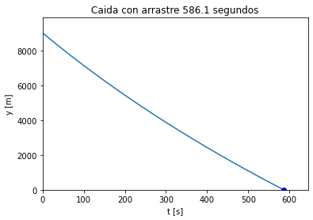

```
tiempo de caida: 586.1 segundos
```

```python
tiempo = caida(9000,0,0.1)
print('tiempo de caida: ' +  str(round(tiempo,2))+ ' segundos')
```

Vemos que al poco tiempo el objeto empieza a caer a velocidad casi constante (por eso la gráfica se vuelve casi lineal) Esta velocidad es la velocidad terminal.

Vemos que el tiempo t es de aprox 586.1s

**(ii) Sin fuerza de arrastre**

En este caso, ponemos a = 0 para que no haya arrastre y graficamos igual que antes

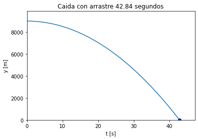

```
tiempo de caida: 42.84 segundos
```

```python
tiempo = caida(9000,0,0.02,a=0,freq = 30)
print('tiempo de caida: ' +  str(round(tiempo,3))+ ' segundos')
```

Vemos que el tiempo en caer es de aprox 42.84 segundos.

Esto coincide con la fórmula usual para calcular el tiempo de caída libre $t = \sqrt{\dfrac{2*y0}{g}} = \sqrt{\dfrac{2*9000}{9.81}} = 42.835$, por lo que el código parece predecirlo bien

## 4.

**El bloque de hierro magnetizado de masa m está unido a un resorte de rigidez k y longitud L. El bloque está en reposo en x = L cuando un electroimán está encendido, ejerciendo una fuerza de repulsión $F = c/x^2$ en el bloque. La ecuación de movimiento resultante es**

$$m \ddot{x} = \dfrac{c}{x^2} - k(x-L)$$

**Determina la amplitud y el periodo, no olvides reportar el error numérico. Resuelve usando el método numérico que prefieras.**

$$ \dfrac{dx}{dt}= v$$$$ \dfrac{d^2 x}{dt^2} = \dfrac{c}{mx^2} - \dfrac{k}{m} (x-L)$$

Definimos la función f que toma a las variables x,v y el tiempo t, los parámetros c,k,l,m y da como resultado las derivadas dx/dt y dv/dt según indica la ecuación diferencial.

```python
from IPython import display

import numpy as np
import matplotlib.pyplot as plt
from pylab import *

def f(r,t,c,k,l,m):
    x = r[0]
    vx = r[1]

    fx = vx
    fvx= c/(x**2*m) -k*(x-l)/m

    return array([fx,fvx],float)
```

Definimos la función Resorte. Esta función toma como entrada el valor inicial de la posición x0, y la velocidad vx0 y el tiempo final hasta el que queremos calcular la solución tf.

El programa da como resultado una gráfica de la función x(t) y la va actualizando de forma animada hasta llegar al tiempo tf.

Además, toma como entrada el valor N que son las iteraciones del método de Runge y la variable freq que al igual que en el inciso anterior, es el número de pasos que tienen que hacerse cada que se quiere actualizar la gráfica. Y toma como entrada los valores c,k,l,m.

Para calcular la amplitud y el periodo, lo que vamos a hacer es registrar cuando en una iteración del Runge Kutta, cambie de signo el valor de vx (para aproximar el punto en el que vx =0). Esto significará que estamos en un máximo o mínimo de x(t) y la función acaba de completar media oscilación. Vamos a ir guardando los valores que toma x y t en estos puntos.

```python
#definimos la función
def resorte(x0,vx0,tf=10,N=1000,c=1,k=1,l=10,m=10
          , titulo="Resorte",
         freq =10):

    #el tiempo inicial es t0=0
    t0 =0
    #iniciamos un contador
    count = 0
    #calculamos h, la magnitud de cada paso en el método de runge
    h = (tf-t0)/N

    #en maximos guardaremos el valor de x cuando la solución alcanza un max o min
    #lo usaremos para calcular la amplitud
    maximos = []
    #En periodos guardaremos el valor de t cuando la solución alcanza un max o min
    # lo usaremos para calcular el periodo. Pues el tiempo entre dos elementos de esta lista
    # será el intervalo de tiempo que toma para hacer media oscilación.
    periodos =[]

    # creamos listas vacías donde iremos guardando los valores de t,x,v
    tpuntos = []
    xpuntos = []
    vxpuntos = []

    #vamos a ir guardando la posición y velocidad en un array r
    r = array([x0,vx0],float)


    #vamos iterando para los tiempos entre t0 y tf en pasos de longitud h
    for t in np.arange(t0,tf,h):
        #agregamos el punto actual a las listas
        tpuntos.append(t)
        xpuntos.append(r[0])
        vxpuntos.append(r[1])

        #aplicamos runge kutta
        k1 = h*f(r,t,c,k,l,m)
        k2 = h*f(r+0.5*k1,t+0.5*h,c,k,l,m)
        k3 = h*f(r+0.5*k2,t+0.5*h,c,k,l,m)
        k4 = h*f(r+k3,t+h,c,k,l,m)
        r += (k1+2*k2+2*k3+k4)/6

        #Si hemos hecho un número de iteraciones múltiplo de freq, actualizamos la grafica
        if count % freq == 0:
            #dibujamos los puntos de posición vs tiempo
            plt.plot(tpuntos,xpuntos,label='posición')
            plt.title("x(t) en tiempo {}".format(str(t)))
            plt.xlabel='tiempo t'
            plt.ylabel='Posición'

            plt.plot(tpuntos[-1],xpuntos[-1],'bo')

            plt.show()
            display.clear_output(wait=True)
        #aumentamos el contador
        count+=1


        #Si nos encontramos en un máximo de x(t) (es decir, v(t) acaba de cambiar de signo)
        if r[1] *vxpuntos[-1]<=0:
            #agregamos el valor de x a la lista de máximos
            maximos.append(r[0])
            # y el valor de t también
            periodos.append(t)




    #Graficamos ya la gráfica final
    plt.plot(tpuntos,xpuntos,label='posición')
    plt.title("x(t) en tiempo {}".format(str(t)))
    plt.xlabel='tiempo t'
    plt.ylabel='Posición'

    plt.plot(tpuntos[-1],xpuntos[-1],'bo')

    plt.show()

    # la función regresa como salida la lista de máximos y de periodos
    return(maximos,periodos)
```

Vamos a aplicar la resolver la ecuación para ciertos valores de c,k,m,l escogidos por mí.

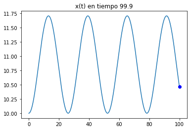

```python
L=10

# y sacamos la lista de máximos y periodos
maximos, periodos= resorte(x0=L,vx0=0,tf=100,l=L,c=50,k=0.5,freq=50,m=10)
```

```python
#la lista de máximos son los valores de x(t) cada que la función alcanza un máximo o mínimo
print(maximos)
```

```
[10.00024998750004, 11.708158775239932, 10.00018455177145, 11.708183523496723, 10.00012902546108, 11.708198571348072, 10.000083409229365, 11.708203918626236]
```

```python
#La amplitud de oscilaciones será aproximadamente la diferencia entre el valor de x
# en uno de los máximos y en uno de los mínimos

amplitud = max(maximos)-min(maximos)

print('se tiene una amplitud de: ', amplitud, ' m')
```

```
se tiene una amplitud de:  1.7081205093968705  m
```

```python
# La lista de periodos devuelve los tiempos en los que la función alcanza un máximo o mínimo
#la diferencia entre dos de estos tiempos seguidos será aprox. la mitad del periodo de oscilación
print(periodos)
```

```
[0.0, 13.0, 26.1, 39.1, 52.2, 65.2, 78.30000000000001, 91.30000000000001]
```

```python
# calculamos todas las diferencias entre dos de estos tiempos consecutivos y promediamos, para
# conseguir un valor promedio del medio periodo de osiclación

suma =0
for i in range(len(periodos)-1):
    suma+= periodos[i+1]-periodos[i]
medio_periodo = suma/(len(periodos)-1)

periodo = 2*medio_periodo

print('se tiene un periodo de ', periodo, ' s')
print('y por tanto una frecuencia de', 1/periodo, ' ciclos por segundo')
```

```
se tiene un periodo de  26.08571428571429  s
y por tanto una frecuencia de 0.038335158817086525  ciclos por segundo
```